# hackathon

oceane_gorke_michelle_hatoum_nader_helali

18/12/2020

```r
knitr::opts_chunk$set(echo = TRUE)
```

## Data Pre-processing

#Loading data

```r
data_train = read.csv('data.csv')
test = read.csv('test.csv')
dim(data_train)
```

```
## [1] 67502    11
```

```r
str(data_train)
```

```
## 'data.frame':    67502 obs. of  11 variables:
##  $ SeriousDlqin2yrs                    : int  0 0 0 0 0 0 0 0 0 0 ...
##  $ RevolvingUtilizationOfUnsecuredLines: num  0.957 0.658 0.907 0.213 0.754 ...
##  $ age                                 : int  40 38 49 74 39 57 30 46 43 43 ...
##  $ NumberOfTime30_59DaysPastDueNotWorse: int  0 1 1 0 0 0 0 0 0 0 ...
##  $ DebtRatio                           : num  0.115 0.0817 0.0246 0.3189 0.1906 ...
##  $ MonthlyIncome                       : num  7.86 8.02 11.06 8.16 8.16 ...
##  $ NumberOfOpenCreditLinesAndLoans     : int  4 2 7 3 8 9 5 13 7 10 ...
##  $ NumberOfTimes90DaysLate             : int  0 1 0 0 0 0 0 0 0 0 ...
##  $ NumberRealEstateLoansOrLines        : int  0 0 1 1 0 4 0 2 1 2 ...
##  $ NumberOfTime60_89DaysPastDueNotWorse: int  0 0 0 0 0 0 0 0 0 0 ...
##  $ NumberOfDependents                  : int  1 0 0 1 0 2 0 2 2 0 ...
```

```r
data <- na.omit(data_train)
```

We can see that there are a lot of NA values, we decide to omit them.

```r
sum(is.na(data))
```

```
## [1] 0
```

```r
head(data)
```

```
##   SeriousDlqin2yrs RevolvingUtilizationOfUnsecuredLines age
## 1                0                            0.9571510  40
## 2                0                            0.6581801  38
## 3                0                            0.9072394  49
## 4                0                            0.2131787  74
## 5                0                            0.7544636  39
## 6                0                            0.1891691  57
##   NumberOfTime30_59DaysPastDueNotWorse  DebtRatio MonthlyIncome
## 1                                    0 0.11500246      7.863651
## 2                                    1 0.08168447      8.020599
## 3                                    1 0.02462012     11.060196
## 4                                    0 0.31889507      8.160804
## 5                                    0 0.19057079      8.160804
## 6                                    0 0.47392773     10.072597
##   NumberOfOpenCreditLinesAndLoans NumberOfTimes90DaysLate
```

[output cut: 20 more lines]

Plus, let’s add that we are working on a classification model, so every regression model are also not an option.

#Logitstic regression

```r
myglm<- glm(SeriousDlqin2yrs ~ .,family=binomial(link='logit') , data = data)
summary(myglm)
```

```
##
## Call:
## glm(formula = SeriousDlqin2yrs ~ ., family = binomial(link = "logit"),
##     data = data)
##
## Deviance Residuals:
##     Min       1Q   Median       3Q      Max
## -6.0639  -0.3588  -0.2454  -0.1922   3.1229
##
## Coefficients:
##                                       Estimate Std. Error z value Pr(>|z|)
## (Intercept)                          -2.131251   0.282967  -7.532 5.00e-14 ***
## RevolvingUtilizationOfUnsecuredLines  1.962461   0.052706  37.234  < 2e-16 ***
## age                                  -0.014322   0.001545  -9.267  < 2e-16 ***
## NumberOfTime30_59DaysPastDueNotWorse  0.374837   0.018080  20.732  < 2e-16 ***
## DebtRatio                             0.350487   0.081243   4.314 1.60e-05 ***
## MonthlyIncome                        -0.176684   0.034149  -5.174 2.29e-07 ***
## NumberOfOpenCreditLinesAndLoans       0.027515   0.004284   6.423 1.34e-10 ***
## NumberOfTimes90DaysLate               0.489321   0.025493  19.194  < 2e-16 ***
## NumberRealEstateLoansOrLines          0.070565   0.017807   3.963 7.41e-05 ***
## NumberOfTime60_89DaysPastDueNotWorse  0.131548   0.037542   3.504 0.000458 ***
## NumberOfDependents                    0.077784   0.015551   5.002 5.68e-07 ***
## ---
## Signif. codes:  0 '***' 0.001 '**' 0.01 '*' 0.05 '.' 0.1 ' ' 1
##
## (Dispersion parameter for binomial family taken to be 1)
##
##     Null deviance: 26974  on 53036  degrees of freedom
## Residual deviance: 21847  on 53026  degrees of freedom
## AIC: 21869
##
## Number of Fisher Scoring iterations: 6
```

```r
pred<- predict(myglm, newdata=test,type = "response")
pred
```

```
##           1           2           3           4           5           6
## 0.019808397 0.131807486 0.024449902 0.082930685 0.212479399 0.051686907
##           7           8           9          10          11          12
## 0.023796834 0.133898325 0.038480216 0.013539847 0.027034286 0.070429495
##          13          14          15          16          17          18
## 0.008585513 0.016726628 0.152285204 0.119954148 0.088400024 0.053772249
##          19          20          21          22          23          24
## 0.030764281 0.043305956 0.060675484 0.014715528 0.033828463 0.027705031
##          25          26          27          28          29          30
## 0.026522865 0.115727327 0.480852900 0.078648116 0.152037276 0.017445471
##          31          32          33          34          35          36
## 0.039448198 0.049432552 0.015166603 0.027119315 0.025523448 0.129340626
##          37          38          39          40          41          42
## 0.113159634 0.045521424 0.052912020 0.124463394 0.043804344 0.079365756
##          43          44          45          46          47          48
## 0.072440243 0.183160132 0.017216275 0.026092987 0.028646543 0.108254876
##          49          50          51          52          53          54
## 0.024349321 0.025510731 0.038314005 0.151416689 0.017252424 0.083969680
##          55          56          57          58          59          60
## 0.034629827 0.038747767 0.051686769 0.028200534 0.999999973 0.145376285
##          61          62          63          64          65          66
## 0.111290391 0.113385225 0.043523827 0.057202817 0.038316559 0.024851984
##          67          68          69          70          71          72
## 0.032011597 0.121423392 0.035045454 0.012951343 0.024433900 0.025015552
##          73          74          75          76          77          78
## 0.033147857 0.023392885 0.064584317 0.024695186 0.024523914 0.241478888
##          79          80          81          82          83          84
## 0.015389124 0.021116510 0.033628008 0.147261306 0.026242711 0.103616035
##          85          86          87          88          89          90
## 0.038008179 0.035787052 0.024433911 0.100345196 0.026120974 0.055567764
##          91          92          93          94          95          96
## 0.098041822 0.035975600 0.021323832 0.079358180 0.014155227 0.102057775
##          97          98          99         100         101         102
## 0.038948221 0.034379443 0.024550792 0.026440040 0.015853726 0.042825598
##         103         104         105         106         107         108
## 0.040377904 0.104208155 0.233556810 0.049220193 0.014460604 0.026544872
##         109         110         111         112         113         114
## 0.044685464 0.077011891 0.017148154 0.022681745 0.021171415 0.016890310
##         115         116         117         118         119         120
## 0.015622882 0.012884543 0.016239271 0.019366126 0.043343142 0.033029414
```

[output cut: 431 more lines]

```
## 0.134692324 0.015135428 0.018857092 0.029547123 0.048983041 0.304934658
##        1417        1418        1419        1420        1421        1422
## 0.025051101 0.137042017 0.111222866 0.030642361 0.279783693 0.023835154
##        1423        1424        1425        1426        1427        1428
## 0.044576020 0.098475349 0.072828087 0.015372737 0.061878203 0.050618842
##        1429        1430        1431        1432        1433        1434
## 0.123178675 0.037893450 0.022797622 0.017870478 0.054506413 0.014155397
##        1435        1436        1437        1438        1439        1440
## 0.243919952 0.034640671 0.120807768 0.022249985 0.460733510 0.043863280
##        1441        1442        1443        1444        1445        1446
## 0.060272986 0.035092878 0.100136083 0.033923118 0.090016495 0.024142400
##        1447        1448        1449        1450        1451        1452
## 0.012716013 0.037568099 0.040005417 0.016034320 0.141482425 0.027407294
##        1453        1454        1455        1456
## 0.032846181 0.042602283 0.023196707 0.272942496
```

```r
y <- ifelse(pred>0.5, "1", "0")
y
```

```
##    1    2    3    4    5    6    7    8    9   10   11   12   13   14   15   16
##  "0"  "0"  "0"  "0"  "0"  "0"  "0"  "0"  "0"  "0"  "0"  "0"  "0"  "0"  "0"  "0"
##   17   18   19   20   21   22   23   24   25   26   27   28   29   30   31   32
##  "0"  "0"  "0"  "0"  "0"  "0"  "0"  "0"  "0"  "0"  "0"  "0"  "0"  "0"  "0"  "0"
##   33   34   35   36   37   38   39   40   41   42   43   44   45   46   47   48
##  "0"  "0"  "0"  "0"  "0"  "0"  "0"  "0"  "0"  "0"  "0"  "0"  "0"  "0"  "0"  "0"
##   49   50   51   52   53   54   55   56   57   58   59   60   61   62   63   64
##  "0"  "0"  "0"  "0"  "0"  "0"  "0"  "0"  "0"  "0"  "1"  "0"  "0"  "0"  "0"  "0"
##   65   66   67   68   69   70   71   72   73   74   75   76   77   78   79   80
##  "0"  "0"  "0"  "0"  "0"  "0"  "0"  "0"  "0"  "0"  "0"  "0"  "0"  "0"  "0"  "0"
##   81   82   83   84   85   86   87   88   89   90   91   92   93   94   95   96
##  "0"  "0"  "0"  "0"  "0"  "0"  "0"  "0"  "0"  "0"  "0"  "0"  "0"  "0"  "0"  "0"
##   97   98   99  100  101  102  103  104  105  106  107  108  109  110  111  112
##  "0"  "0"  "0"  "0"  "0"  "0"  "0"  "0"  "0"  "0"  "0"  "0"  "0"  "0"  "0"  "0"
##  113  114  115  116  117  118  119  120  121  122  123  124  125  126  127  128
##  "0"  "0"  "0"  "0"  "0"  "0"  "0"  "0"  "0"  "0"  "0"  "0"  "0"  "0"  "0"  "0"
##  129  130  131  132  133  134  135  136  137  138  139  140  141  142  143  144
##  "0"  "0"  "0"  "0"  "0"  "0"  "0"  "0"  "0"  "0"  "0"  "0"  "0"  "0"  "0"  "0"
##  145  146  147  148  149  150  151  152  153  154  155  156  157  158  159  160
##  "0"  "0"  "0"  "0"  "0"  "0"  "0"  "0"  "0"  "0"  "0"  "0"  "0"  "0"  "0"  "0"
##  161  162  163  164  165  166  167  168  169  170  171  172  173  174  175  176
##  "0"  "0"  "0"  "0"  "0"  "0"  "0"  "0"  "0"  "0"  "0"  "0"  "0"  "0"  "0"  "0"
##  177  178  179  180  181  182  183  184  185  186  187  188  189  190  191  192
##  "0"  "0"  "0"  "0"  "0"  "0"  "0"  "0"  "0"  "0"  "0"  "0"  "0"  "0"  "0"  "0"
##  193  194  195  196  197  198  199  200  201  202  203  204  205  206  207  208
##  "0"  "0"  "0"  "0"  "0"  "0"  "0"  "0"  "0"  "0"  "0"  "0"  "0"  "1"  "0"  "0"
##  209  210  211  212  213  214  215  216  217  218  219  220  221  222  223  224
##  "0"  "0"  "0"  "0"  "0"  "0"  "0"  "0"  "0"  "0"  "0"  "0"  "0"  "0"  "0"  "0"
##  225  226  227  228  229  230  231  232  233  234  235  236  237  238  239  240
##  "0"  "0"  "0"  "0"  "0"  "0"  "0"  "0"  "0"  "0"  "0"  "0"  "0"  "0"  "0"  "0"
##  241  242  243  244  245  246  247  248  249  250  251  252  253  254  255  256
##  "0"  "0"  "0"  "1"  "0"  "0"  "0"  "0"  "0"  "0"  "0"  "0"  "0"  "0"  "0"  "0"
##  257  258  259  260  261  262  263  264  265  266  267  268  269  270  271  272
##  "0"  "0"  "0"  "0"  "0"  "0"  "0"  "0"  "0"  "0"  "0"  "0"  "0"  "0"  "0"  "0"
##  273  274  275  276  277  278  279  280  281  282  283  284  285  286  287  288
##  "0"  "0"  "0"  "1"  "0"  "0"  "0"  "0"  "0"  "0"  "0"  "0"  "0"  "0"  "0"  "0"
##  289  290  291  292  293  294  295  296  297  298  299  300  301  302  303  304
##  "0"  "0"  "0"  "0"  "0"  "0"  "0"  "1"  "0"  "0"  "0"  "0"  "0"  "0"  "0"  "0"
##  305  306  307  308  309  310  311  312  313  314  315  316  317  318  319  320
##  "0"  "0"  "0"  "0"  "0"  "0"  "0"  "0"  "0"  "0"  "0"  "0"  "1"  "0"  "0"  "0"
```

[output cut: 127 more lines]

```
##  "0"  "0"  "0"  "0"  "0"  "0"  "0"  "0"  "0"  "0"  "0"  "0"  "0"  "0"  "0"  "0"
## 1345 1346 1347 1348 1349 1350 1351 1352 1353 1354 1355 1356 1357 1358 1359 1360
##  "0"  "0"  "1"  "0"  "0"  "0"  "0"  "0"  "0"  "0"  "0"  "0"  "0"  "0"  "0"  "0"
## 1361 1362 1363 1364 1365 1366 1367 1368 1369 1370 1371 1372 1373 1374 1375 1376
##  "0"  "0"  "0"  "0"  "0"  "0"  "0"  "0"  "0"  "0"  "0"  "0"  "0"  "0"  "0"  "0"
## 1377 1378 1379 1380 1381 1382 1383 1384 1385 1386 1387 1388 1389 1390 1391 1392
##  "0"  "0"  "0"  "0"  "0"  "0"  "0"  "0"  "0"  "1"  "0"  "0"  "0"  "0"  "0"  "0"
## 1393 1394 1395 1396 1397 1398 1399 1400 1401 1402 1403 1404 1405 1406 1407 1408
##  "0"  "0"  "0"  "0"  "0"  "0"  "0"  "0"  "0"  "0"  "0"  "0"  "0"  "0"  "0"  "0"
## 1409 1410 1411 1412 1413 1414 1415 1416 1417 1418 1419 1420 1421 1422 1423 1424
##  "0"  "0"  "0"  "0"  "0"  "0"  "0"  "0"  "0"  "0"  "0"  "0"  "0"  "0"  "0"  "0"
## 1425 1426 1427 1428 1429 1430 1431 1432 1433 1434 1435 1436 1437 1438 1439 1440
##  "0"  "0"  "0"  "0"  "0"  "0"  "0"  "0"  "0"  "0"  "0"  "0"  "0"  "0"  "0"  "0"
## 1441 1442 1443 1444 1445 1446 1447 1448 1449 1450 1451 1452 1453 1454 1455 1456
##  "0"  "0"  "0"  "0"  "0"  "0"  "0"  "0"  "0"  "0"  "0"  "0"  "0"  "0"  "0"  "0"
```

We can see that every feature is significant in our model (low p-value and 3 stars) so we don’t have a lead on what variable could be omitted from our model. We can also notice a very high AIC value, which means that our model is not optimised. We then know that there are better models we could use, so let’s continue digging.

#Decision Trees

```r
library(rpart)
library(rpart.plot)
tree1 <- rpart(SeriousDlqin2yrs ~., data=data)
summary(tree1)
```

```
## Call:
## rpart(formula = SeriousDlqin2yrs ~ ., data = data)
##   n= 53037
##
##           CP nsplit rel error    xerror       xstd
## 1 0.10906699      0 1.0000000 1.0000241 0.01460324
## 2 0.02663082      1 0.8909330 0.8910593 0.01306574
## 3 0.01498264      2 0.8643022 0.8645052 0.01221926
## 4 0.01115291      3 0.8493195 0.8520321 0.01196997
## 5 0.01000000      4 0.8381666 0.8445800 0.01203183
##
## Variable importance
##              NumberOfTimes90DaysLate RevolvingUtilizationOfUnsecuredLines
##                                   69                                   16
## NumberOfTime30_59DaysPastDueNotWorse NumberOfTime60_89DaysPastDueNotWorse
##                                   11                                    4
##      NumberOfOpenCreditLinesAndLoans
##                                    1
##
## Node number 1: 53037 observations,    complexity param=0.109067
##   mean=0.07025284, MSE=0.06531738
##   left son=2 (50105 obs) right son=3 (2932 obs)
##   Primary splits:
##       NumberOfTimes90DaysLate              < 0.5          to the left,  improve=0.109067000, (0 missing)
##       NumberOfTime60_89DaysPastDueNotWorse < 0.5          to the left,  improve=0.074691820, (0 missing)
##       RevolvingUtilizationOfUnsecuredLines < 0.7391443    to the left,  improve=0.065665250, (0 missing)
##       NumberOfTime30_59DaysPastDueNotWorse < 0.5          to the left,  improve=0.058868340, (0 missing)
##       age                                  < 55.5         to the right, improve=0.008956548, (0 missing)
##   Surrogate splits:
##       NumberOfTime60_89DaysPastDueNotWorse < 2.5          to the left,  agree=0.947, adj=0.040, (0 split)
##       NumberOfTime30_59DaysPastDueNotWorse < 9.5          to the left,  agree=0.946, adj=0.023, (0 split)
##
## Node number 2: 50105 observations,    complexity param=0.02663082
##   mean=0.04983535, MSE=0.04735178
##   left son=4 (37204 obs) right son=5 (12901 obs)
##   Primary splits:
##       RevolvingUtilizationOfUnsecuredLines < 0.507875     to the left,  improve=0.038884360, (0 missing)
##       NumberOfTime60_89DaysPastDueNotWorse < 0.5          to the left,  improve=0.034808260, (0 missing)
##       NumberOfTime30_59DaysPastDueNotWorse < 0.5          to the left,  improve=0.034098970, (0 missing)
##       DebtRatio                            < 0.4465453    to the left,  improve=0.008497534, (0 missing)
```

[output cut: 37 more lines]

```
##       RevolvingUtilizationOfUnsecuredLines < 1.036297     to the left,  agree=0.747, adj=0.007, (0 split)
##       NumberRealEstateLoansOrLines         < 9.5          to the left,  agree=0.745, adj=0.001, (0 split)
##       NumberOfOpenCreditLinesAndLoans      < 36           to the left,  agree=0.745, adj=0.000, (0 split)
##
## Node number 6: 1841 observations
##   mean=0.3307985, MSE=0.2213708
##
## Node number 7: 1091 observations
##   mean=0.568286, MSE=0.245337
##
## Node number 10: 9607 observations
##   mean=0.08556261, MSE=0.07824165
##
## Node number 11: 3294 observations
##   mean=0.2310261, MSE=0.177653
```

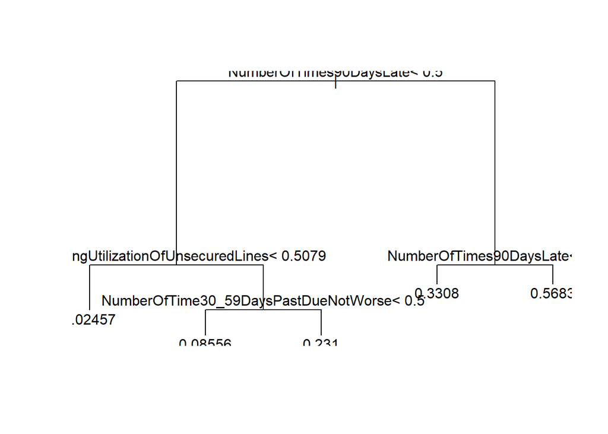

```r
plot(tree1)
text(tree1)
```

This was the decison tree that gave us the best score : 0.94230. We decided te use decision tree because it was the logical continuation after the logistic regression. Indeed, decision trees were the most likely to give us good results for this classification problem. The score was good but we tried to do better.

#Random Forest

```r
library(randomForest)
fit <- randomForest(as.factor(SeriousDlqin2yrs) ~ . -MonthlyIncome,
                    data=data,
                    importance=TRUE,
                    ntree=25, keep.forest = TRUE)
sum(is.na(data$SeriousDlqin2yrs))
```

```
## [1] 0
```

```r
pred <- predict(fit, test)
pred
```

```
##    1    2    3    4    5    6    7    8    9   10   11   12   13   14   15   16
##    0    0    0    0    0    0    0    0    0    0    0    0    0    0    0    0
##   17   18   19   20   21   22   23   24   25   26   27   28   29   30   31   32
##    0    0    0    0    0    0    0    0    0    0    0    0    0    0    0    0
##   33   34   35   36   37   38   39   40   41   42   43   44   45   46   47   48
##    0    0    0    0    0    0    0    0    0    0    0    0    0    0    0    0
##   49   50   51   52   53   54   55   56   57   58   59   60   61   62   63   64
##    0    0    0    0    0    0    0    0    0    0    1    0    0    0    0    0
##   65   66   67   68   69   70   71   72   73   74   75   76   77   78   79   80
##    0    0    0    0    0    0    0    0    0    0    0    0    0    0    0    0
##   81   82   83   84   85   86   87   88   89   90   91   92   93   94   95   96
##    0    0    0    0    0    0    0    0    0    0    0    0    0    0    0    0
##   97   98   99  100  101  102  103  104  105  106  107  108  109  110  111  112
##    0    0    0    0    0    0    0    0    0    0    0    0    0    0    0    0
##  113  114  115  116  117  118  119  120  121  122  123  124  125  126  127  128
```

[output cut: 168 more lines]

The randomforest method also gave the same score.

```r
library(gbm)
```

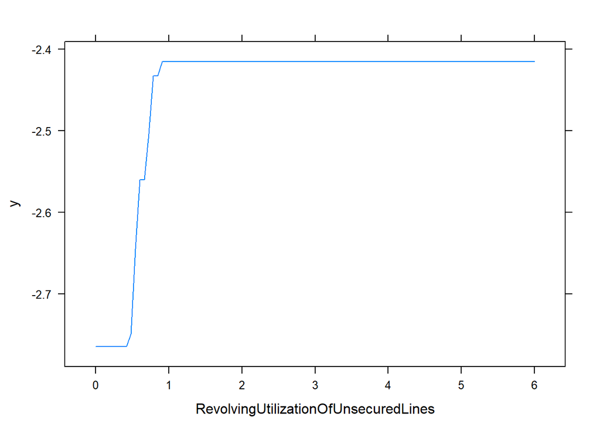

```r
model_boost <- gbm(SeriousDlqin2yrs~ .,data=data, distribution="bernoulli",interaction.depth=1,shrinkage=0.01)
#tried to change interaction.depth (1, 2, 3), shrinkage
plot(model_boost)
```

```r
pred <- predict(model_boost, newdata=test)
```

```
## Using 100 trees...
```

```r
pred
```

```
##    [1] -2.8931463 -2.5438113 -2.8931463 -2.6489785 -1.1582317 -1.6887065
##    [7] -2.8931463 -2.5616306 -2.7120066 -2.8931463 -2.8931463 -2.8931463
##   [13] -2.8931463 -2.8931463 -2.5438113 -1.3571908 -2.6322042 -2.6489785
##   [19] -2.8931463 -2.8931463 -2.8931463 -2.8931463 -2.8931463 -2.8931463
##   [25] -2.8931463 -2.5438113 -0.5857963 -2.8931463 -2.5438113 -2.8931463
##   [31] -2.8931463 -2.7120066 -2.8931463 -2.8931463 -2.8931463 -2.3626715
##   [37] -2.0344040 -2.8931463 -2.6674352 -1.5075667 -2.8931463 -2.6165945
##   [43] -2.7736281 -2.5438113 -2.8931463 -2.8931463 -2.7120066 -2.5971503
##   [49] -2.8931463 -2.8931463 -2.8931463 -2.5438113 -2.8931463 -2.6889209
##   [55] -2.8931463 -2.8931463 -2.8931463 -2.8931463 -0.5215405 -2.5438113
##   [61] -2.5438113 -2.5438113 -2.7120066 -2.8931463 -2.8931463 -2.8931463
##   [67] -2.8931463 -2.5438113 -2.7120066 -2.8931463 -2.8931463 -2.8931463
##   [73] -2.8931463 -2.8931463 -2.8931463 -2.8931463 -2.8931463 -0.8156131
##   [79] -2.8931463 -2.8931463 -2.8931463 -2.5438113 -2.8931463 -2.5426191
##   [85] -2.6489785 -2.7579401 -2.8931463 -2.3626715 -2.8931463 -2.6889209
```

[output cut: 228 more lines]

```r
y <- ifelse(pred>0.5, "1", "0")
y
```

```
##    [1] "0" "0" "0" "0" "0" "0" "0" "0" "0" "0" "0" "0" "0" "0" "0" "0" "0" "0"
##   [19] "0" "0" "0" "0" "0" "0" "0" "0" "0" "0" "0" "0" "0" "0" "0" "0" "0" "0"
##   [37] "0" "0" "0" "0" "0" "0" "0" "0" "0" "0" "0" "0" "0" "0" "0" "0" "0" "0"
##   [55] "0" "0" "0" "0" "0" "0" "0" "0" "0" "0" "0" "0" "0" "0" "0" "0" "0" "0"
##   [73] "0" "0" "0" "0" "0" "0" "0" "0" "0" "0" "0" "0" "0" "0" "0" "0" "0" "0"
##   [91] "0" "0" "0" "0" "0" "0" "0" "0" "0" "0" "0" "0" "0" "0" "0" "0" "0" "0"
##  [109] "0" "0" "0" "0" "0" "0" "0" "0" "0" "0" "0" "0" "0" "0" "0" "0" "0" "0"
##  [127] "0" "0" "0" "0" "0" "0" "0" "0" "0" "0" "0" "0" "0" "0" "0" "0" "0" "0"
##  [145] "0" "0" "0" "0" "0" "0" "0" "0" "0" "0" "0" "0" "0" "0" "0" "0" "0" "0"
##  [163] "0" "0" "0" "0" "0" "0" "0" "0" "0" "0" "0" "0" "0" "0" "0" "0" "0" "0"
##  [181] "0" "0" "0" "0" "0" "0" "0" "0" "0" "0" "0" "0" "0" "0" "0" "0" "0" "0"
##  [199] "0" "0" "0" "0" "0" "0" "0" "0" "0" "0" "0" "0" "0" "0" "0" "0" "0" "0"
##  [217] "0" "0" "0" "0" "0" "0" "0" "0" "0" "0" "0" "0" "0" "0" "0" "0" "0" "0"
##  [235] "0" "0" "0" "0" "0" "0" "0" "0" "0" "0" "0" "0" "0" "0" "0" "0" "0" "0"
##  [253] "0" "0" "0" "0" "0" "0" "0" "0" "0" "0" "0" "0" "0" "0" "0" "0" "0" "0"
```

[output cut: 66 more lines]

```r
model_Bagging = randomForest(as.factor(SeriousDlqin2yrs) ~ ., data = data, mtry = sqrt(10),
                             importance = TRUE)

pred <- predict(model_Bagging, newdata=test)
pred
```

```
##    1    2    3    4    5    6    7    8    9   10   11   12   13   14   15   16
##    0    0    0    0    0    0    0    0    0    0    0    0    0    0    0    0
##   17   18   19   20   21   22   23   24   25   26   27   28   29   30   31   32
##    0    0    0    0    0    0    0    0    0    0    0    0    0    0    0    0
##   33   34   35   36   37   38   39   40   41   42   43   44   45   46   47   48
##    0    0    0    0    0    0    0    0    0    0    0    0    0    0    0    0
##   49   50   51   52   53   54   55   56   57   58   59   60   61   62   63   64
##    0    0    0    0    0    0    0    0    0    0    0    0    0    0    0    0
##   65   66   67   68   69   70   71   72   73   74   75   76   77   78   79   80
##    0    0    0    0    0    0    0    0    0    0    0    0    0    0    0    0
##   81   82   83   84   85   86   87   88   89   90   91   92   93   94   95   96
##    0    0    0    0    0    0    0    0    0    0    0    0    0    0    0    0
##   97   98   99  100  101  102  103  104  105  106  107  108  109  110  111  112
##    0    0    0    0    0    0    0    0    0    0    0    0    0    0    0    0
##  113  114  115  116  117  118  119  120  121  122  123  124  125  126  127  128
```

[output cut: 168 more lines]

```r
#no need to do ifelse on this one, it was directly between 0 and 1s

y <- ifelse(pred>0.5, "1", "0")
y
```

```
##    [1] NA NA NA NA NA NA NA NA NA NA NA NA NA NA NA NA NA NA NA NA NA NA NA NA
##   [25] NA NA NA NA NA NA NA NA NA NA NA NA NA NA NA NA NA NA NA NA NA NA NA NA
##   [49] NA NA NA NA NA NA NA NA NA NA NA NA NA NA NA NA NA NA NA NA NA NA NA NA
##   [73] NA NA NA NA NA NA NA NA NA NA NA NA NA NA NA NA NA NA NA NA NA NA NA NA
##   [97] NA NA NA NA NA NA NA NA NA NA NA NA NA NA NA NA NA NA NA NA NA NA NA NA
##  [121] NA NA NA NA NA NA NA NA NA NA NA NA NA NA NA NA NA NA NA NA NA NA NA NA
##  [145] NA NA NA NA NA NA NA NA NA NA NA NA NA NA NA NA NA NA NA NA NA NA NA NA
##  [169] NA NA NA NA NA NA NA NA NA NA NA NA NA NA NA NA NA NA NA NA NA NA NA NA
##  [193] NA NA NA NA NA NA NA NA NA NA NA NA NA NA NA NA NA NA NA NA NA NA NA NA
##  [217] NA NA NA NA NA NA NA NA NA NA NA NA NA NA NA NA NA NA NA NA NA NA NA NA
##  [241] NA NA NA NA NA NA NA NA NA NA NA NA NA NA NA NA NA NA NA NA NA NA NA NA
##  [265] NA NA NA NA NA NA NA NA NA NA NA NA NA NA NA NA NA NA NA NA NA NA NA NA
##  [289] NA NA NA NA NA NA NA NA NA NA NA NA NA NA NA NA NA NA NA NA NA NA NA NA
##  [313] NA NA NA NA NA NA NA NA NA NA NA NA NA NA NA NA NA NA NA NA NA NA NA NA
##  [337] NA NA NA NA NA NA NA NA NA NA NA NA NA NA NA NA NA NA NA NA NA NA NA NA
```

[output cut: 46 more lines]

```r
printcp(tree1)
```

```
##
## Regression tree:
## rpart(formula = SeriousDlqin2yrs ~ ., data = data)
##
## Variables actually used in tree construction:
## [1] NumberOfTime30_59DaysPastDueNotWorse NumberOfTimes90DaysLate
## [3] RevolvingUtilizationOfUnsecuredLines
##
## Root node error: 3464.2/53037 = 0.065317
##
## n= 53037
##
##         CP nsplit rel error  xerror     xstd
## 1 0.109067      0   1.00000 1.00002 0.014603
## 2 0.026631      1   0.89093 0.89106 0.013066
## 3 0.014983      2   0.86430 0.86451 0.012219
## 4 0.011153      3   0.84932 0.85203 0.011970
## 5 0.010000      4   0.83817 0.84458 0.012032
```

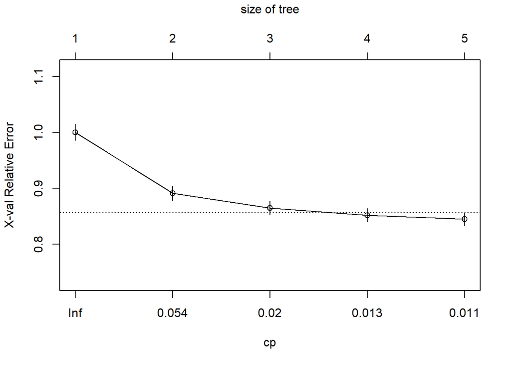

```r
#method prune
#min for indice = 5
#min = 0.84480 + 0.012076
# = 0.856876
#cp = 0.014983

plotcp(tree1)
```

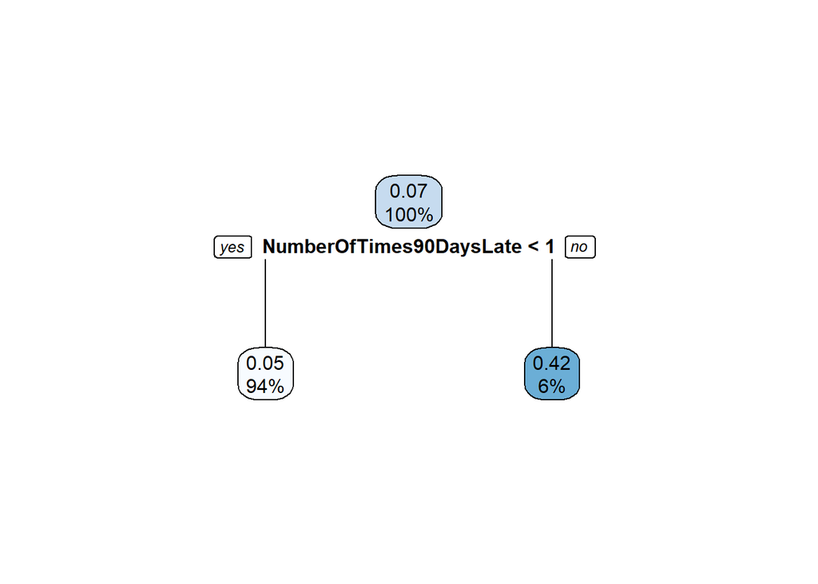

```r
tree1_prune <- prune(tree1,cp=  0.026631)
rpart.plot(tree1_prune)
```

```r
tree1_pred = predict(tree1, newdata=test)
tree1_pred
```

```
##          1          2          3          4          5          6          7
## 0.02456725 0.08556261 0.02456725 0.02456725 0.33079848 0.33079848 0.02456725
##          8          9         10         11         12         13         14
## 0.08556261 0.02456725 0.02456725 0.02456725 0.02456725 0.02456725 0.02456725
##         15         16         17         18         19         20         21
## 0.08556261 0.33079848 0.08556261 0.02456725 0.02456725 0.02456725 0.02456725
##         22         23         24         25         26         27         28
## 0.02456725 0.02456725 0.02456725 0.02456725 0.08556261 0.33079848 0.02456725
##         29         30         31         32         33         34         35
## 0.08556261 0.02456725 0.02456725 0.02456725 0.02456725 0.02456725 0.02456725
##         36         37         38         39         40         41         42
## 0.23102611 0.08556261 0.02456725 0.08556261 0.33079848 0.02456725 0.02456725
##         43         44         45         46         47         48         49
## 0.08556261 0.08556261 0.02456725 0.02456725 0.02456725 0.08556261 0.02456725
##         50         51         52         53         54         55         56
## 0.02456725 0.02456725 0.08556261 0.02456725 0.08556261 0.02456725 0.02456725
##         57         58         59         60         61         62         63
## 0.02456725 0.02456725 0.56828598 0.08556261 0.08556261 0.08556261 0.02456725
##         64         65         66         67         68         69         70
## 0.02456725 0.02456725 0.02456725 0.02456725 0.08556261 0.02456725 0.02456725
##         71         72         73         74         75         76         77
## 0.02456725 0.02456725 0.02456725 0.02456725 0.02456725 0.02456725 0.02456725
##         78         79         80         81         82         83         84
## 0.33079848 0.02456725 0.02456725 0.02456725 0.08556261 0.02456725 0.23102611
##         85         86         87         88         89         90         91
## 0.02456725 0.08556261 0.02456725 0.23102611 0.02456725 0.08556261 0.08556261
##         92         93         94         95         96         97         98
## 0.02456725 0.02456725 0.08556261 0.02456725 0.02456725 0.02456725 0.02456725
##         99        100        101        102        103        104        105
## 0.02456725 0.02456725 0.02456725 0.02456725 0.02456725 0.23102611 0.33079848
##        106        107        108        109        110        111        112
## 0.08556261 0.02456725 0.02456725 0.02456725 0.08556261 0.02456725 0.02456725
##        113        114        115        116        117        118        119
## 0.02456725 0.02456725 0.02456725 0.02456725 0.02456725 0.02456725 0.02456725
##        120        121        122        123        124        125        126
## 0.02456725 0.02456725 0.02456725 0.08556261 0.02456725 0.02456725 0.02456725
##        127        128        129        130        131        132        133
## 0.02456725 0.23102611 0.02456725 0.23102611 0.02456725 0.02456725 0.02456725
##        134        135        136        137        138        139        140
## 0.02456725 0.23102611 0.02456725 0.02456725 0.02456725 0.02456725 0.02456725
```

[output cut: 361 more lines]

```
## 0.02456725 0.02456725 0.08556261 0.02456725 0.02456725 0.33079848 0.02456725
##       1408       1409       1410       1411       1412       1413       1414
## 0.02456725 0.02456725 0.08556261 0.02456725 0.02456725 0.02456725 0.02456725
##       1415       1416       1417       1418       1419       1420       1421
## 0.02456725 0.23102611 0.02456725 0.02456725 0.08556261 0.02456725 0.33079848
##       1422       1423       1424       1425       1426       1427       1428
## 0.02456725 0.08556261 0.08556261 0.08556261 0.02456725 0.08556261 0.02456725
##       1429       1430       1431       1432       1433       1434       1435
## 0.23102611 0.02456725 0.02456725 0.02456725 0.02456725 0.02456725 0.23102611
##       1436       1437       1438       1439       1440       1441       1442
## 0.02456725 0.08556261 0.02456725 0.23102611 0.02456725 0.02456725 0.08556261
##       1443       1444       1445       1446       1447       1448       1449
## 0.08556261 0.02456725 0.33079848 0.02456725 0.02456725 0.02456725 0.08556261
##       1450       1451       1452       1453       1454       1455       1456
## 0.02456725 0.08556261 0.02456725 0.02456725 0.02456725 0.02456725 0.33079848
```

```r
y <- ifelse(tree1_pred>0.5, "1", "0")
y
```

```
##    1    2    3    4    5    6    7    8    9   10   11   12   13   14   15   16
##  "0"  "0"  "0"  "0"  "0"  "0"  "0"  "0"  "0"  "0"  "0"  "0"  "0"  "0"  "0"  "0"
##   17   18   19   20   21   22   23   24   25   26   27   28   29   30   31   32
##  "0"  "0"  "0"  "0"  "0"  "0"  "0"  "0"  "0"  "0"  "0"  "0"  "0"  "0"  "0"  "0"
##   33   34   35   36   37   38   39   40   41   42   43   44   45   46   47   48
##  "0"  "0"  "0"  "0"  "0"  "0"  "0"  "0"  "0"  "0"  "0"  "0"  "0"  "0"  "0"  "0"
##   49   50   51   52   53   54   55   56   57   58   59   60   61   62   63   64
##  "0"  "0"  "0"  "0"  "0"  "0"  "0"  "0"  "0"  "0"  "1"  "0"  "0"  "0"  "0"  "0"
##   65   66   67   68   69   70   71   72   73   74   75   76   77   78   79   80
##  "0"  "0"  "0"  "0"  "0"  "0"  "0"  "0"  "0"  "0"  "0"  "0"  "0"  "0"  "0"  "0"
##   81   82   83   84   85   86   87   88   89   90   91   92   93   94   95   96
##  "0"  "0"  "0"  "0"  "0"  "0"  "0"  "0"  "0"  "0"  "0"  "0"  "0"  "0"  "0"  "0"
##   97   98   99  100  101  102  103  104  105  106  107  108  109  110  111  112
##  "0"  "0"  "0"  "0"  "0"  "0"  "0"  "0"  "0"  "0"  "0"  "0"  "0"  "0"  "0"  "0"
##  113  114  115  116  117  118  119  120  121  122  123  124  125  126  127  128
##  "0"  "0"  "0"  "0"  "0"  "0"  "0"  "0"  "0"  "0"  "0"  "0"  "0"  "0"  "0"  "0"
##  129  130  131  132  133  134  135  136  137  138  139  140  141  142  143  144
##  "0"  "0"  "0"  "0"  "0"  "0"  "0"  "0"  "0"  "0"  "0"  "0"  "0"  "0"  "0"  "0"
##  145  146  147  148  149  150  151  152  153  154  155  156  157  158  159  160
##  "0"  "0"  "0"  "0"  "0"  "0"  "1"  "0"  "1"  "0"  "0"  "0"  "0"  "0"  "0"  "0"
##  161  162  163  164  165  166  167  168  169  170  171  172  173  174  175  176
##  "0"  "0"  "0"  "0"  "0"  "0"  "0"  "0"  "0"  "0"  "0"  "0"  "0"  "0"  "0"  "0"
##  177  178  179  180  181  182  183  184  185  186  187  188  189  190  191  192
##  "0"  "0"  "0"  "0"  "0"  "1"  "0"  "0"  "0"  "0"  "0"  "0"  "0"  "0"  "0"  "0"
##  193  194  195  196  197  198  199  200  201  202  203  204  205  206  207  208
##  "0"  "0"  "0"  "0"  "0"  "0"  "0"  "0"  "0"  "0"  "0"  "0"  "0"  "1"  "0"  "0"
##  209  210  211  212  213  214  215  216  217  218  219  220  221  222  223  224
##  "0"  "0"  "0"  "0"  "0"  "0"  "0"  "0"  "0"  "0"  "0"  "0"  "0"  "0"  "0"  "0"
##  225  226  227  228  229  230  231  232  233  234  235  236  237  238  239  240
##  "0"  "0"  "0"  "0"  "0"  "0"  "0"  "0"  "0"  "0"  "0"  "0"  "0"  "0"  "0"  "0"
##  241  242  243  244  245  246  247  248  249  250  251  252  253  254  255  256
##  "0"  "0"  "0"  "1"  "0"  "0"  "0"  "0"  "0"  "0"  "0"  "0"  "0"  "0"  "0"  "0"
##  257  258  259  260  261  262  263  264  265  266  267  268  269  270  271  272
##  "0"  "0"  "0"  "0"  "0"  "0"  "0"  "0"  "0"  "0"  "0"  "0"  "0"  "0"  "0"  "0"
##  273  274  275  276  277  278  279  280  281  282  283  284  285  286  287  288
##  "0"  "0"  "0"  "1"  "0"  "1"  "0"  "0"  "0"  "0"  "0"  "0"  "0"  "0"  "0"  "0"
##  289  290  291  292  293  294  295  296  297  298  299  300  301  302  303  304
##  "0"  "0"  "0"  "0"  "0"  "0"  "0"  "1"  "0"  "0"  "0"  "0"  "0"  "0"  "0"  "0"
##  305  306  307  308  309  310  311  312  313  314  315  316  317  318  319  320
##  "0"  "0"  "0"  "0"  "0"  "0"  "0"  "0"  "0"  "0"  "0"  "0"  "1"  "0"  "0"  "0"
```

[output cut: 127 more lines]

```
##  "0"  "0"  "0"  "0"  "0"  "0"  "0"  "0"  "0"  "0"  "0"  "0"  "0"  "0"  "0"  "0"
## 1345 1346 1347 1348 1349 1350 1351 1352 1353 1354 1355 1356 1357 1358 1359 1360
##  "0"  "0"  "0"  "0"  "0"  "0"  "0"  "0"  "0"  "0"  "0"  "0"  "0"  "0"  "0"  "0"
## 1361 1362 1363 1364 1365 1366 1367 1368 1369 1370 1371 1372 1373 1374 1375 1376
##  "0"  "0"  "0"  "0"  "0"  "0"  "0"  "0"  "0"  "0"  "0"  "0"  "0"  "0"  "0"  "0"
## 1377 1378 1379 1380 1381 1382 1383 1384 1385 1386 1387 1388 1389 1390 1391 1392
##  "0"  "0"  "0"  "0"  "0"  "0"  "0"  "0"  "0"  "0"  "0"  "0"  "0"  "0"  "0"  "0"
## 1393 1394 1395 1396 1397 1398 1399 1400 1401 1402 1403 1404 1405 1406 1407 1408
##  "0"  "0"  "0"  "0"  "0"  "0"  "0"  "0"  "0"  "0"  "0"  "0"  "0"  "0"  "0"  "0"
## 1409 1410 1411 1412 1413 1414 1415 1416 1417 1418 1419 1420 1421 1422 1423 1424
##  "0"  "0"  "0"  "0"  "0"  "0"  "0"  "0"  "0"  "0"  "0"  "0"  "0"  "0"  "0"  "0"
## 1425 1426 1427 1428 1429 1430 1431 1432 1433 1434 1435 1436 1437 1438 1439 1440
##  "0"  "0"  "0"  "0"  "0"  "0"  "0"  "0"  "0"  "0"  "0"  "0"  "0"  "0"  "0"  "0"
## 1441 1442 1443 1444 1445 1446 1447 1448 1449 1450 1451 1452 1453 1454 1455 1456
##  "0"  "0"  "0"  "0"  "0"  "0"  "0"  "0"  "0"  "0"  "0"  "0"  "0"  "0"  "0"  "0"
```

```r
#score : 0,94230
```

This also gave us the same score.

To conclude, we used a bunch of models that gave us the same score but the score was pretty high so we were satisfied. However, if we had more time we would probably have changed some parameters to see if the score would increase.